# Dynamic Pricing & Demand Analysis Suite

data-viz

XGBoost

analytics

notebook

python

Author

Atila Madai

Published

June 16, 2025

# Dynamic Hotel Pricing Optimization

### Project Goal

This project explores how to build a **trading floor-inspired, real-time dynamic pricing engine** for hotel inventory.

The system leverages: - Advanced **demand forecasting** models - **Price elasticity modeling** under competition - **Revenue optimization** via mathematical and ML-based methods - **Real-time simulation** and visualization for business impact assessment

### Background

The global hotel market exceeds **$1.3 trillion**, with increasing adoption of **dynamic pricing** by major hotel chains and OTAs.  
Building a flexible, API-first, ML-driven pricing engine represents a major opportunity both for industry players and as a standalone service offering.

Inspired by companies building real-time, data-driven marketplaces, this project demonstrates how such a system can be designed and implemented for the travel and hospitality sector.

### Project Structure

```
DynamicHotelPricingOptimization/
├── data/                      # Raw and processed data
├── notebooks/                 # Jupyter notebooks with modeling and results
├── src/                       # Python scripts for core functionality
├── reports/                   # Generated visualizations and slides
└── tests/                     # (Optional) unit tests
```

### Getting Started

#### Recommended tools:

- Python 3.9+
- Jupyter Notebook or Databricks
- GitHub for versioning

### Author

Atila Madai  
*This Article is in development*

This post combines four related notebooks exploring dynamic pricing and demand analytics:

1. **EDA: Dynamic Hotel Pricing Optimization**
2. **Demand Forecasting**
3. **Price Elasticity Modeling**
4. **Price Elasticity Modeling with XGBoost**

## 1. EDA: Dynamic Hotel Pricing Optimization

# 🏨 Dynamic Hotel Pricing Optimization

## 📊 01_EDA - Exploratory Data Analysis

**Goal:** Explore the dataset, understand key patterns and prepare features for modeling.

|  | hotel | is_canceled | lead_time | arrival_date_year | arrival_date_month | arrival_date_week_number | arrival_date_day_of_month | stays_in_weekend_nights | stays_in_week_nights | adults | ... | deposit_type | agent | company | days_in_waiting_list | customer_type | adr | required_car_parking_spaces | total_of_special_requests | reservation_status | reservation_status_date |
| --- | --- | --- | --- | --- | --- | --- | --- | --- | --- | --- | --- | --- | --- | --- | --- | --- | --- | --- | --- | --- | --- |
| 0 | Resort Hotel | 0 | 342 | 2015 | July | 27 | 1 | 0 | 0 | 2 | ... | No Deposit | NaN | NaN | 0 | Transient | 0.0 | 0 | 0 | Check-Out | 2015-07-01 |
| 1 | Resort Hotel | 0 | 737 | 2015 | July | 27 | 1 | 0 | 0 | 2 | ... | No Deposit | NaN | NaN | 0 | Transient | 0.0 | 0 | 0 | Check-Out | 2015-07-01 |
| 2 | Resort Hotel | 0 | 7 | 2015 | July | 27 | 1 | 0 | 1 | 1 | ... | No Deposit | NaN | NaN | 0 | Transient | 75.0 | 0 | 0 | Check-Out | 2015-07-02 |
| 3 | Resort Hotel | 0 | 13 | 2015 | July | 27 | 1 | 0 | 1 | 1 | ... | No Deposit | 304.0 | NaN | 0 | Transient | 75.0 | 0 | 0 | Check-Out | 2015-07-02 |
| 4 | Resort Hotel | 0 | 14 | 2015 | July | 27 | 1 | 0 | 2 | 2 | ... | No Deposit | 240.0 | NaN | 0 | Transient | 98.0 | 0 | 1 | Check-Out | 2015-07-03 |

5 rows × 32 columns

```
<class 'pandas.core.frame.DataFrame'>
RangeIndex: 119390 entries, 0 to 119389
Data columns (total 32 columns):
 #   Column                          Non-Null Count   Dtype
---  ------                          --------------   -----
 0   hotel                           119390 non-null  object
 1   is_canceled                     119390 non-null  int64
 2   lead_time                       119390 non-null  int64
 3   arrival_date_year               119390 non-null  int64
 4   arrival_date_month              119390 non-null  object
 5   arrival_date_week_number        119390 non-null  int64
 6   arrival_date_day_of_month       119390 non-null  int64
 7   stays_in_weekend_nights         119390 non-null  int64
 8   stays_in_week_nights            119390 non-null  int64
 9   adults                          119390 non-null  int64
```

[output cut: 24 more lines]

|  | is_canceled | lead_time | arrival_date_year | arrival_date_week_number | arrival_date_day_of_month | stays_in_weekend_nights | stays_in_week_nights | adults | children | babies | is_repeated_guest | previous_cancellations | previous_bookings_not_canceled | booking_changes | agent | company | days_in_waiting_list | adr | required_car_parking_spaces | total_of_special_requests |
| --- | --- | --- | --- | --- | --- | --- | --- | --- | --- | --- | --- | --- | --- | --- | --- | --- | --- | --- | --- | --- |
| count | 119390.000000 | 119390.000000 | 119390.000000 | 119390.000000 | 119390.000000 | 119390.000000 | 119390.000000 | 119390.000000 | 119386.000000 | 119390.000000 | 119390.000000 | 119390.000000 | 119390.000000 | 119390.000000 | 103050.000000 | 6797.000000 | 119390.000000 | 119390.000000 | 119390.000000 | 119390.000000 |
| mean | 0.370416 | 104.011416 | 2016.156554 | 27.165173 | 15.798241 | 0.927599 | 2.500302 | 1.856403 | 0.103890 | 0.007949 | 0.031912 | 0.087118 | 0.137097 | 0.221124 | 86.693382 | 189.266735 | 2.321149 | 101.831122 | 0.062518 | 0.571363 |
| std | 0.482918 | 106.863097 | 0.707476 | 13.605138 | 8.780829 | 0.998613 | 1.908286 | 0.579261 | 0.398561 | 0.097436 | 0.175767 | 0.844336 | 1.497437 | 0.652306 | 110.774548 | 131.655015 | 17.594721 | 50.535790 | 0.245291 | 0.792798 |
| min | 0.000000 | 0.000000 | 2015.000000 | 1.000000 | 1.000000 | 0.000000 | 0.000000 | 0.000000 | 0.000000 | 0.000000 | 0.000000 | 0.000000 | 0.000000 | 0.000000 | 1.000000 | 6.000000 | 0.000000 | -6.380000 | 0.000000 | 0.000000 |
| 25% | 0.000000 | 18.000000 | 2016.000000 | 16.000000 | 8.000000 | 0.000000 | 1.000000 | 2.000000 | 0.000000 | 0.000000 | 0.000000 | 0.000000 | 0.000000 | 0.000000 | 9.000000 | 62.000000 | 0.000000 | 69.290000 | 0.000000 | 0.000000 |
| 50% | 0.000000 | 69.000000 | 2016.000000 | 28.000000 | 16.000000 | 1.000000 | 2.000000 | 2.000000 | 0.000000 | 0.000000 | 0.000000 | 0.000000 | 0.000000 | 0.000000 | 14.000000 | 179.000000 | 0.000000 | 94.575000 | 0.000000 | 0.000000 |
| 75% | 1.000000 | 160.000000 | 2017.000000 | 38.000000 | 23.000000 | 2.000000 | 3.000000 | 2.000000 | 0.000000 | 0.000000 | 0.000000 | 0.000000 | 0.000000 | 0.000000 | 229.000000 | 270.000000 | 0.000000 | 126.000000 | 0.000000 | 1.000000 |
| max | 1.000000 | 737.000000 | 2017.000000 | 53.000000 | 31.000000 | 19.000000 | 50.000000 | 55.000000 | 10.000000 | 10.000000 | 1.000000 | 26.000000 | 72.000000 | 21.000000 | 535.000000 | 543.000000 | 391.000000 | 5400.000000 | 8.000000 | 5.000000 |

|  | stay_length | lead_time | booking_month | weekday |
| --- | --- | --- | --- | --- |
| 0 | 0 | 342 | 7 | 2 |
| 1 | 0 | 737 | 7 | 2 |
| 2 | 1 | 7 | 7 | 3 |
| 3 | 1 | 13 | 7 | 3 |
| 4 | 2 | 14 | 7 | 4 |

```
Cancellation Rate: 37.04%
```

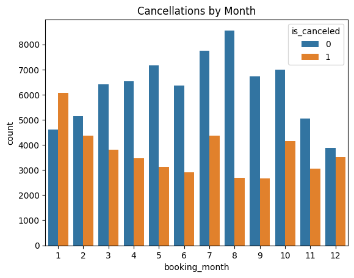

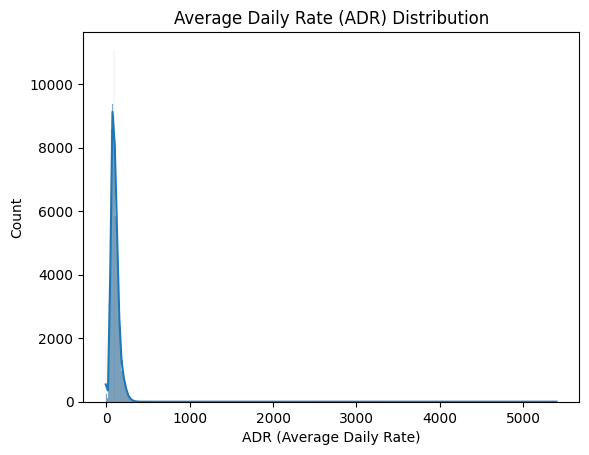

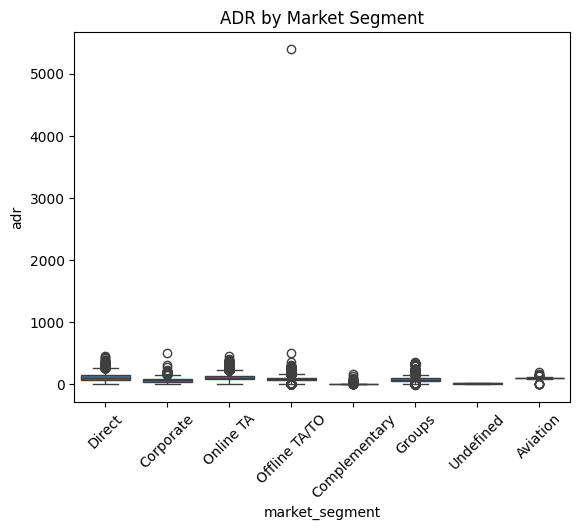

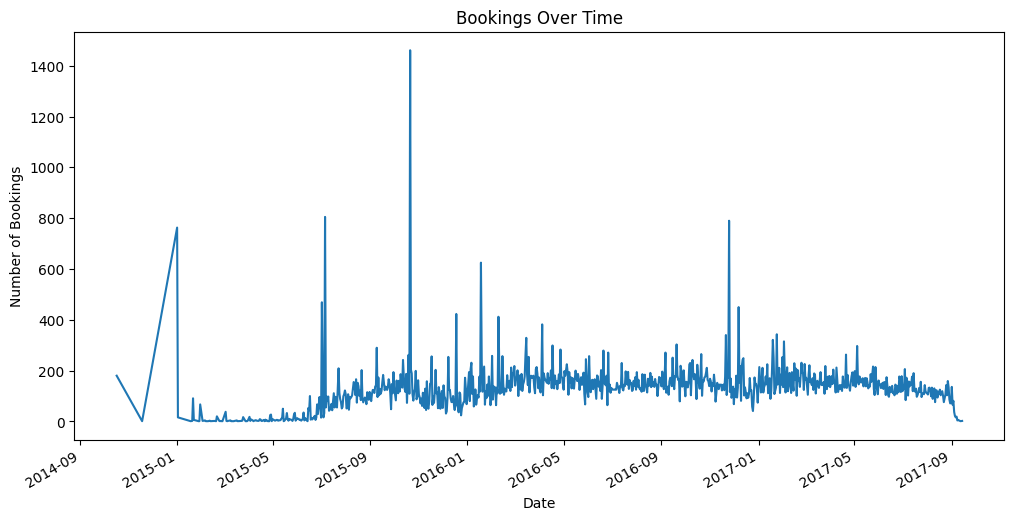

Source: 🏨 Dynamic Hotel Pricing Optimization

## 2. Demand Forecasting

# 🏨 Dynamic Hotel Pricing Optimization

## 📈 02_Demand Forecasting

**Goal:** Build models to forecast demand (number of bookings) per hotel and date.

|  | reservation_status_date | bookings |
| --- | --- | --- |
| 0 | 2014-10-17 | 180 |
| 1 | 2014-11-18 | 1 |
| 2 | 2015-01-01 | 763 |
| 3 | 2015-01-02 | 16 |
| 4 | 2015-01-18 | 1 |

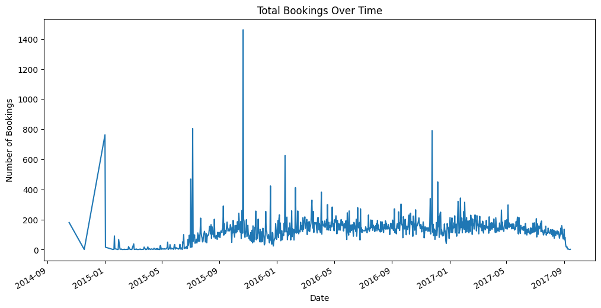

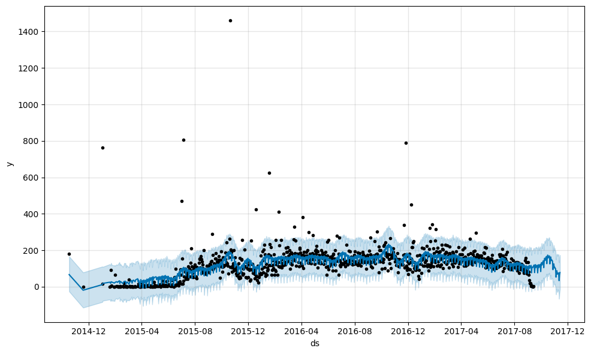

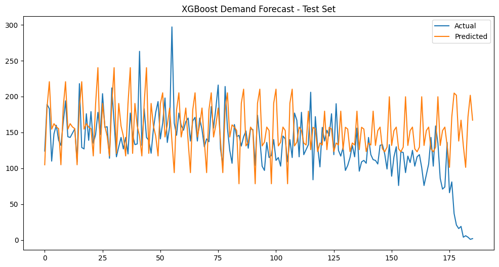

Source: 🏨 Dynamic Hotel Pricing Optimization

## 3. Price Elasticity Modeling

# 🏨 Dynamic Hotel Pricing Optimization

## 📉 03_Price Elasticity Modeling

**Goal:** Model how booking demand responds to changes in price, and estimate optimal pricing zones.

|  | hotel | is_canceled | lead_time | arrival_date_year | arrival_date_month | arrival_date_week_number | arrival_date_day_of_month | stays_in_weekend_nights | stays_in_week_nights | adults | ... | deposit_type | agent | company | days_in_waiting_list | customer_type | adr | required_car_parking_spaces | total_of_special_requests | reservation_status | reservation_status_date |
| --- | --- | --- | --- | --- | --- | --- | --- | --- | --- | --- | --- | --- | --- | --- | --- | --- | --- | --- | --- | --- | --- |
| 0 | Resort Hotel | 0 | 342 | 2015 | July | 27 | 1 | 0 | 0 | 2 | ... | No Deposit | NaN | NaN | 0 | Transient | 0.0 | 0 | 0 | Check-Out | 2015-07-01 |
| 1 | Resort Hotel | 0 | 737 | 2015 | July | 27 | 1 | 0 | 0 | 2 | ... | No Deposit | NaN | NaN | 0 | Transient | 0.0 | 0 | 0 | Check-Out | 2015-07-01 |
| 2 | Resort Hotel | 0 | 7 | 2015 | July | 27 | 1 | 0 | 1 | 1 | ... | No Deposit | NaN | NaN | 0 | Transient | 75.0 | 0 | 0 | Check-Out | 2015-07-02 |
| 3 | Resort Hotel | 0 | 13 | 2015 | July | 27 | 1 | 0 | 1 | 1 | ... | No Deposit | 304.0 | NaN | 0 | Transient | 75.0 | 0 | 0 | Check-Out | 2015-07-02 |
| 4 | Resort Hotel | 0 | 14 | 2015 | July | 27 | 1 | 0 | 2 | 2 | ... | No Deposit | 240.0 | NaN | 0 | Transient | 98.0 | 0 | 1 | Check-Out | 2015-07-03 |

5 rows × 32 columns

|  | price_bucket | bookings |
| --- | --- | --- |
| 0 | (0, 50] | 7706 |
| 1 | (50, 100] | 33972 |
| 2 | (100, 150] | 21520 |
| 3 | (150, 200] | 7184 |
| 4 | (200, 300] | 2848 |
| 5 | (300, 500] | 187 |
| 6 | (500, 1000] | 2 |

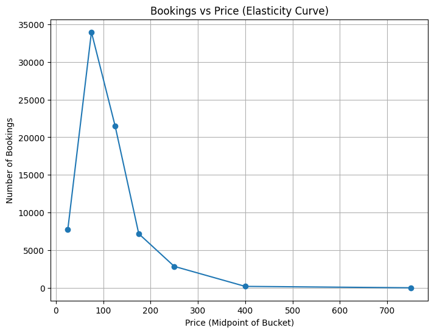

```
                            OLS Regression Results
==============================================================================
Dep. Variable:               bookings   R-squared:                       0.598
Model:                            OLS   Adj. R-squared:                  0.518
Method:                 Least Squares   F-statistic:                     7.441
Date:                Sat, 05 Jul 2025   Prob (F-statistic):             0.0414
Time:                        20:15:04   Log-Likelihood:                -14.821
No. Observations:                   7   AIC:                             33.64
Df Residuals:                       5   BIC:                             33.53
Df Model:                           1
Covariance Type:            nonrobust
==============================================================================
                 coef    std err          t      P>|t|      [0.025      0.975]
------------------------------------------------------------------------------
const         19.5084      4.513      4.323      0.008       7.909      31.108
price_mid     -2.3678      0.868     -2.728      0.041      -4.599      -0.137
==============================================================================
Omnibus:                          nan   Durbin-Watson:                   1.033
Prob(Omnibus):                    nan   Jarque-Bera (JB):                1.053
Skew:                          -0.709   Prob(JB):                        0.591
Kurtosis:                       1.734   Cond. No.                         27.0
==============================================================================

Notes:
[1] Standard Errors assume that the covariance matrix of the errors is correctly specified.
```

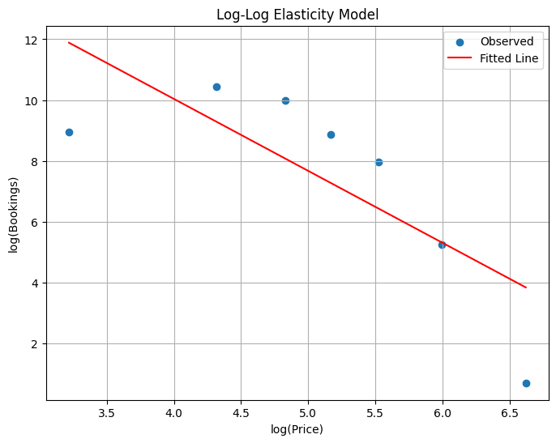

Source: 🏨 Dynamic Hotel Pricing Optimization

## 4. Price Elasticity Modeling (XGBoost)

# 🏨 Dynamic Hotel Pricing Optimization

## 🚀 Advanced Elasticity Modeling → XGBoost Regressor

**Goal:** Model complex, non-linear price elasticity using XGBoost.

|  | adr | market_segment_encoded | hotel_encoded | day_of_week | month | bookings |
| --- | --- | --- | --- | --- | --- | --- |
| 0 | -6.38 | 4 | 1 | 2 | 3 | 1 |
| 1 | 0.00 | 0 | 0 | 1 | 11 | 1 |
| 2 | 0.00 | 0 | 0 | 2 | 6 | 3 |
| 3 | 0.00 | 0 | 0 | 4 | 7 | 1 |
| 4 | 0.00 | 1 | 0 | 0 | 1 | 1 |

```
RMSE: 2.99
```

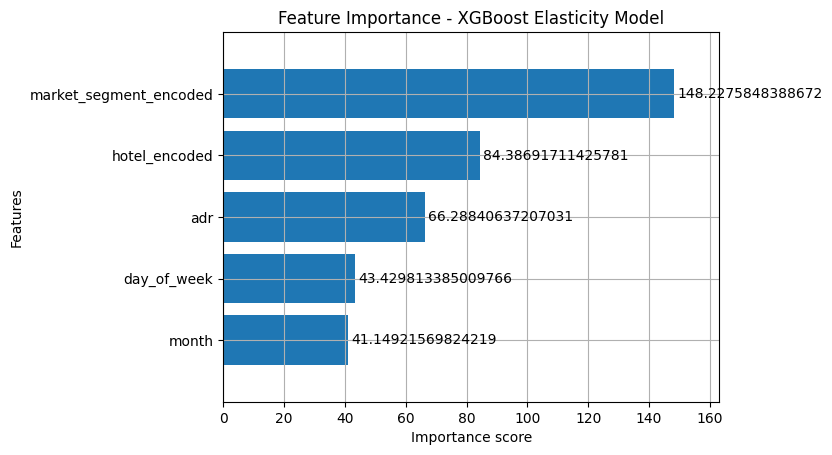

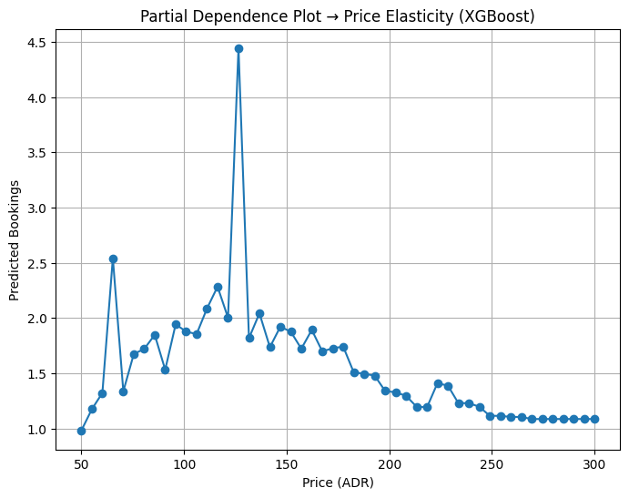

Source: 🏨 Dynamic Hotel Pricing Optimization